# Problem statement

## Diff equation :

Consider the pendulum, subject to a control signal u

$$ml^{2}\ddot{θ}+b\dot{θ}+mglsin(θ)=u$$

## State vertor :

$$X =\begin{pmatrix} θ \\ \dot{θ} \end{pmatrix}$$

# Assumptotic stability

## Intuition first !

- In this section we will analyse system asumptotic stability given the system stability states
- In fact the system got two stable states , the first at $θ=0$ and the second at $θ=\pi$ but the question is : do the system behave the same at this two diferent positions ? let's see visualy

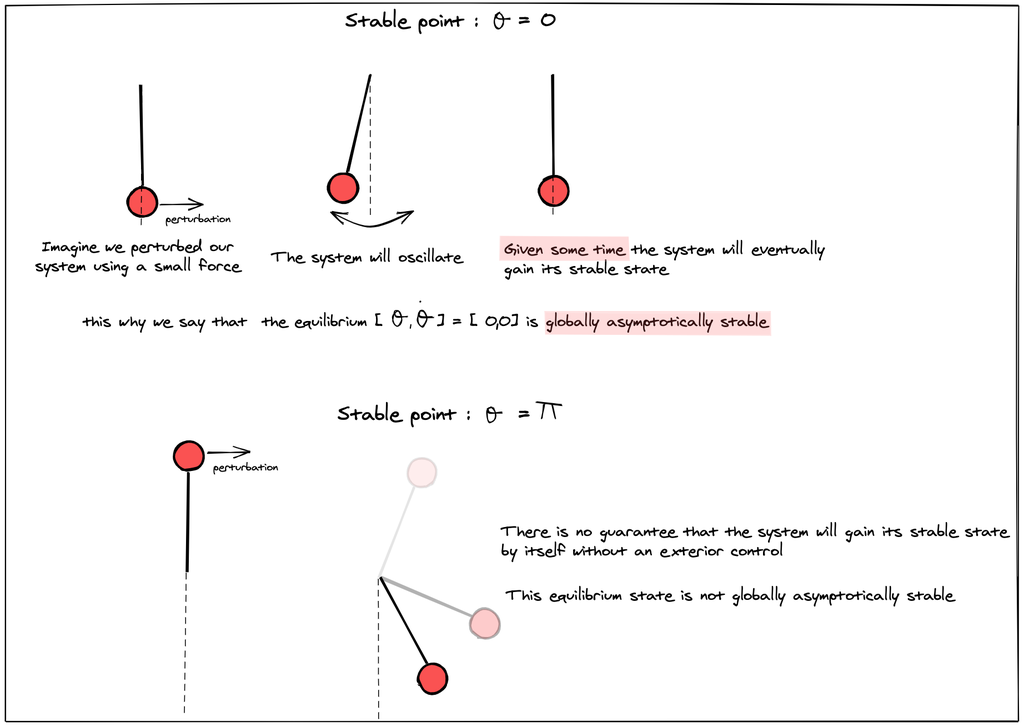

  ## How can we quantify this using linear algebra ?
- to proove the asymptoric stability of an equilibrium point we start by linearizing our system ### Case 1 : $θ=0$
- recall that we have a differential equation that model our system dynamics $$ml^{2}\ddot{θ}+b\dot{θ}+mglsin(θ)=0$$
- linearizing the system given our equilibrium state (See lectures) output this sumplified linear system : $$\dot x = Ax$$ where : $A = \begin{pmatrix} 0 & 1 \\ \frac{-g}{l} & \frac{-b}{ml^{2}} \end{pmatrix}$
- to verify the asymptotic stability we just check the matix A eigen values
- a negative real part would mean that this equilibrium state is asymptotic stable !
- to do this we will use **numpy.linalg module**

```python
import numpy.linalg as linalg
b=0.5;m=1.0;l=1.0;g=9.81
A=np.array([[0,1],[-g/l,-b/(m*l**2)]])
eign_vals,_=linalg.eig(A)
eign_vals
```

```
array([-0.25+3.12209865j, -0.25-3.12209865j])
```

- As you can see the eigen values have both negative real parts wich means verify the asymptotic stability ! ### Case 2 : $θ=\pi$
- for the second case we linearize our system again given this new equilibrium state $$\dot x = Ax$$ where : $A = \begin{pmatrix} 0 & 1 \\ \frac{g}{l} & \frac{-b}{ml^{2}} \end{pmatrix}$

```python
import numpy.linalg as linalg
b=0.5;m=1.0;l=1.0;g=9.81
A=np.array([[0,1],[g/l,-b/(m*l**2)]])
eign_vals,_=linalg.eig(A)
eign_vals
```

```
array([ 2.89205347, -3.39205347])
```

- for this case we got one of the eign values with a positive pole thus we cant verify the asymptoic stability at $θ=\pi$ ### Conclusion
- we can conclude that the system poles can help us decide about the asymptotic stability thus figure out if we need some kind of control (in a way to tune its poles a.k.a pole placement )